# bellabeat_case_study

Brian Ondiso

2023-10-07

## About The Company

Bellabeat, a femtech company with a strong focus on data-driven wellness, is known for creating stylish and technologically advanced wellness products. They have also established themselves as a rapidly growing provider of wellness subscription services tailored for women. The popularity of their Leaf and Ivy wearables has allowed the brand to enter global markets and initiate conversations within the industry about the significance of innovation in the design and creation of tech products.

## 1. Ask

Key Task: Analyze smart device usage data in order to gain insight and help guide marketing strategy for Bellabeat to reveal more opportunities for growth.

## Key Stakeholders

Urška Sršen: Bellabeat’s cofounder and Chief Creative Officer Bellabeat marketing analytics team

## 2. Prepare

Data Source: FitBit Fitness Tracker Data by MÖBIUS Thirty eligible Fitbit users consented to the submission of personal tracker data, including minute-level output for physical activity, heart rate, and sleep monitoring. Individual reports can be parsed by export session ID (column A) or timestamp (column B). Variation between output represents use of different types of Fitbit trackers and individual tracking behaviors/preferences. The data set contains 18 csv files.

## Roccc Analysis

*Reliability : Low – dataset was collected from 30 individuals whose gender is unknown.* Originality : Low – third party data collect using Amazon Mechanical Turk. *Comprehensive : Medium – dataset contains multiple fields on daily activity intensity, calories used, daily steps taken, daily sleep time and weight record.* Current : Low – This data is from May 2016, that means data is not current and user habits may have changed over the period of time.

*Limitations of dataset

Data of only 30 users is availale, a larger sample size is preferred for the more accurate analysis. Age of the users is unknown. Therefore ideal judgement criteria can not be defined. Only 8 users have submitted their weight and 14 unique users submitted their heart rate reading.

## Installing and loading common packages and libraries

```r
library(tidyverse)
library(janitor)
library(here)
library(lubridate)
```

## Upload your CSV files to R

Remember to upload your CSV files to your project from the relevant data source: [FitBit data] (https://www.kaggle.com/arashnic/fitbit)

```r
daily_activity <- read.csv("Data/FitBit Data/Fitabase Data 4.12.16-5.12.16/dailyActivity_merged.csv")
sleep_day <- read.csv("Data/FitBit Data/Fitabase Data 4.12.16-5.12.16/sleepDay_merged.csv")
heart_rate_seconds <- read.csv("Data/FitBit Data/Fitabase Data 4.12.16-5.12.16/heartrate_seconds_merged.csv")
weight_log <- read.csv("Data/FitBit Data/Fitabase Data 4.12.16-5.12.16/weightLogInfo_merged.csv")
hour_calories <- read.csv("Data/FitBit Data/Fitabase Data 4.12.16-5.12.16/hourlyCalories_merged.csv")
hour_intensitities <- read.csv("Data/FitBit Data/Fitabase Data 4.12.16-5.12.16/hourlyIntensities_merged.csv")
hour_steps <- read.csv("Data/FitBit Data/Fitabase Data 4.12.16-5.12.16/hourlySteps_merged.csv")
```

## Exploring a few key tables

```r
head(daily_activity, 2)
```

```
##           Id ActivityDate TotalSteps TotalDistance TrackerDistance
## 1 1503960366    4/12/2016      13162          8.50            8.50
## 2 1503960366    4/13/2016      10735          6.97            6.97
##   LoggedActivitiesDistance VeryActiveDistance ModeratelyActiveDistance
## 1                        0               1.88                     0.55
## 2                        0               1.57                     0.69
##   LightActiveDistance SedentaryActiveDistance VeryActiveMinutes
## 1                6.06                       0                25
## 2                4.71                       0                21
##   FairlyActiveMinutes LightlyActiveMinutes SedentaryMinutes Calories
## 1                  13                  328              728     1985
## 2                  19                  217              776     1797
```

```r
glimpse(sleep_day)
```

```
## Rows: 413
## Columns: 5
## $ Id                 <dbl> 1503960366, 1503960366, 1503960366, 1503960366, 150…
## $ SleepDay           <chr> "4/12/2016 12:00:00 AM", "4/13/2016 12:00:00 AM", "…
## $ TotalSleepRecords  <int> 1, 2, 1, 2, 1, 1, 1, 1, 1, 1, 1, 1, 1, 1, 1, 1, 1, …
## $ TotalMinutesAsleep <int> 327, 384, 412, 340, 700, 304, 360, 325, 361, 430, 2…
## $ TotalTimeInBed     <int> 346, 407, 442, 367, 712, 320, 377, 364, 384, 449, 3…
```

```r
glimpse(heart_rate_seconds)
```

```
## Rows: 2,483,658
## Columns: 3
## $ Id    <dbl> 2022484408, 2022484408, 2022484408, 2022484408, 2022484408, 2022…
## $ Time  <chr> "4/12/2016 7:21:00 AM", "4/12/2016 7:21:05 AM", "4/12/2016 7:21:…
## $ Value <int> 97, 102, 105, 103, 101, 95, 91, 93, 94, 93, 92, 89, 83, 61, 60, …
```

```r
glimpse(hour_calories)
```

```
## Rows: 22,099
## Columns: 3
## $ Id           <dbl> 1503960366, 1503960366, 1503960366, 1503960366, 150396036…
## $ ActivityHour <chr> "4/12/2016 12:00:00 AM", "4/12/2016 1:00:00 AM", "4/12/20…
## $ Calories     <int> 81, 61, 59, 47, 48, 48, 48, 47, 68, 141, 99, 76, 73, 66, …
```

```r
glimpse(hour_intensitities)
```

```
## Rows: 22,099
## Columns: 4
## $ Id               <dbl> 1503960366, 1503960366, 1503960366, 1503960366, 15039…
## $ ActivityHour     <chr> "4/12/2016 12:00:00 AM", "4/12/2016 1:00:00 AM", "4/1…
## $ TotalIntensity   <int> 20, 8, 7, 0, 0, 0, 0, 0, 13, 30, 29, 12, 11, 6, 36, 5…
## $ AverageIntensity <dbl> 0.333333, 0.133333, 0.116667, 0.000000, 0.000000, 0.0…
```

```r
glimpse(hour_steps)
```

```
## Rows: 22,099
## Columns: 3
## $ Id           <dbl> 1503960366, 1503960366, 1503960366, 1503960366, 150396036…
## $ ActivityHour <chr> "4/12/2016 12:00:00 AM", "4/12/2016 1:00:00 AM", "4/12/20…
## $ StepTotal    <int> 373, 160, 151, 0, 0, 0, 0, 0, 250, 1864, 676, 360, 253, 2…
```

```r
glimpse(weight_log)
```

```
## Rows: 67
## Columns: 8
## $ Id             <dbl> 1503960366, 1503960366, 1927972279, 2873212765, 2873212…
## $ Date           <chr> "5/2/2016 11:59:59 PM", "5/3/2016 11:59:59 PM", "4/13/2…
## $ WeightKg       <dbl> 52.6, 52.6, 133.5, 56.7, 57.3, 72.4, 72.3, 69.7, 70.3, …
## $ WeightPounds   <dbl> 115.9631, 115.9631, 294.3171, 125.0021, 126.3249, 159.6…
## $ Fat            <int> 22, NA, NA, NA, NA, 25, NA, NA, NA, NA, NA, NA, NA, NA,…
## $ BMI            <dbl> 22.65, 22.65, 47.54, 21.45, 21.69, 27.45, 27.38, 27.25,…
## $ IsManualReport <chr> "True", "True", "False", "True", "True", "True", "True"…
## $ LogId          <dbl> 1.462234e+12, 1.462320e+12, 1.460510e+12, 1.461283e+12,…
```

## How many unique participants are there in each dataframe?

```r
n_distinct(daily_activity$Id)
```

```
## [1] 33
```

```r
n_distinct(sleep_day$Id)
```

```
## [1] 24
```

```r
n_distinct(heart_rate_seconds$Id)
```

```
## [1] 14
```

```r
n_distinct(weight_log$Id)
```

```
## [1] 8
```

There are 33 participants in the daily activity data, 24 participants in the sleep data 14 users in the heart rate records and 8 participants in recorded their weights.

What are some quick summary statistics we’d want to know about each data frame?

```r
daily_activity %>%
  select(TotalSteps,SedentaryMinutes,Calories,TotalDistance) %>%
  summary()
```

```
##    TotalSteps    SedentaryMinutes    Calories    TotalDistance
##  Min.   :    0   Min.   :   0.0   Min.   :   0   Min.   : 0.000
##  1st Qu.: 3790   1st Qu.: 729.8   1st Qu.:1828   1st Qu.: 2.620
##  Median : 7406   Median :1057.5   Median :2134   Median : 5.245
##  Mean   : 7638   Mean   : 991.2   Mean   :2304   Mean   : 5.490
##  3rd Qu.:10727   3rd Qu.:1229.5   3rd Qu.:2793   3rd Qu.: 7.713
##  Max.   :36019   Max.   :1440.0   Max.   :4900   Max.   :28.030
```

```r
sleep_day %>%
  select(TotalTimeInBed, TotalMinutesAsleep) %>%
  summary()
```

```
##  TotalTimeInBed  TotalMinutesAsleep
##  Min.   : 61.0   Min.   : 58.0
##  1st Qu.:403.0   1st Qu.:361.0
##  Median :463.0   Median :433.0
##  Mean   :458.6   Mean   :419.5
##  3rd Qu.:526.0   3rd Qu.:490.0
##  Max.   :961.0   Max.   :796.0
```

```r
weight_log %>% select(WeightKg, BMI) %>% summary()
```

```
##     WeightKg           BMI
##  Min.   : 52.60   Min.   :21.45
##  1st Qu.: 61.40   1st Qu.:23.96
##  Median : 62.50   Median :24.39
##  Mean   : 72.04   Mean   :25.19
##  3rd Qu.: 85.05   3rd Qu.:25.56
##  Max.   :133.50   Max.   :47.54
```

BMI is a simple index of weight-to-height that is commonly used to classify underweight, overweight and obesity in adults

We will put them into 5 categories BMI <17.0: thinness BMI <18.5: underweight BMI 18.5-24.9: normal weight BMI ≥25.0: overweight BMI ≥30.0: obesity.

```r
weight_log_bmi <- weight_log %>%
  mutate(user_type = case_when(
    BMI < 17 ~ "thinness",
    BMI < 18.5 ~ "underweight",
    BMI >= 18.5 & BMI < 24.9 ~ "normal weight",
    BMI >= 25 ~ "overweight",
    BMI >= 30 ~ "obesity"
  ))

head(weight_log_bmi)
```

```
##           Id                  Date WeightKg WeightPounds Fat   BMI
## 1 1503960366  5/2/2016 11:59:59 PM     52.6     115.9631  22 22.65
## 2 1503960366  5/3/2016 11:59:59 PM     52.6     115.9631  NA 22.65
## 3 1927972279  4/13/2016 1:08:52 AM    133.5     294.3171  NA 47.54
## 4 2873212765 4/21/2016 11:59:59 PM     56.7     125.0021  NA 21.45
## 5 2873212765 5/12/2016 11:59:59 PM     57.3     126.3249  NA 21.69
## 6 4319703577 4/17/2016 11:59:59 PM     72.4     159.6147  25 27.45
##   IsManualReport        LogId     user_type
## 1           True 1.462234e+12 normal weight
## 2           True 1.462320e+12 normal weight
## 3          False 1.460510e+12    overweight
## 4           True 1.461283e+12 normal weight
## 5           True 1.463098e+12 normal weight
## 6           True 1.460938e+12    overweight
```

We put them in percentage

```r
percentage_bmi <- weight_log_bmi %>%
  group_by(user_type) %>%
  summarise(total= n()) %>%
  mutate(total_percent = scales::percent (total/sum(total)))

head(percentage_bmi)
```

```
## # A tibble: 2 × 3
##   user_type     total total_percent
##   <chr>         <int> <chr>
## 1 normal weight    34 50.7%
## 2 overweight       33 49.3%
```

Now we visualize the findings for presentation

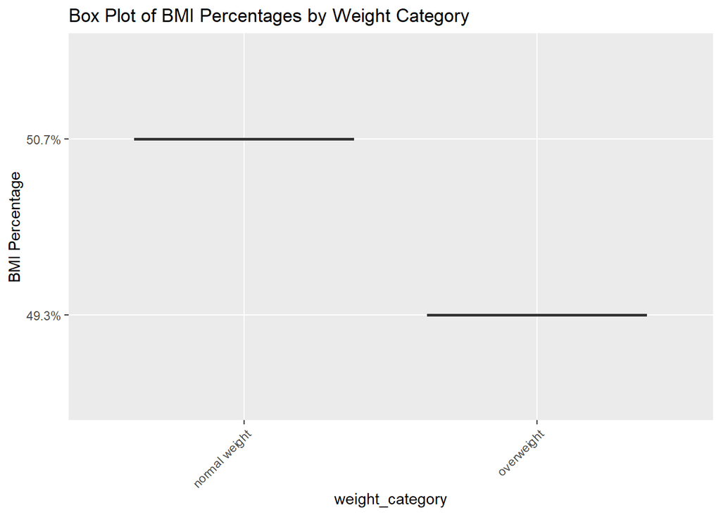

```r
ggplot(percentage_bmi, aes(x = user_type, y = total_percent)) +
  geom_boxplot() +
  labs(
    x = "weight_category",
    y = "BMI Percentage",
    title = "Box Plot of BMI Percentages by Weight Category"
  ) +
  theme(axis.text.x = element_text(angle = 45, hjust = 1))
```

This shows that 49.3% are overweight. The company can invest in weight loss supliment and also send artcles about weight management to their customers.

## Plotting a few explorations

The relationship between steps taken in a day and Calories scatter plot shows a poaitive realtionship, meaning the more steps take in a day, the more calories burnt.

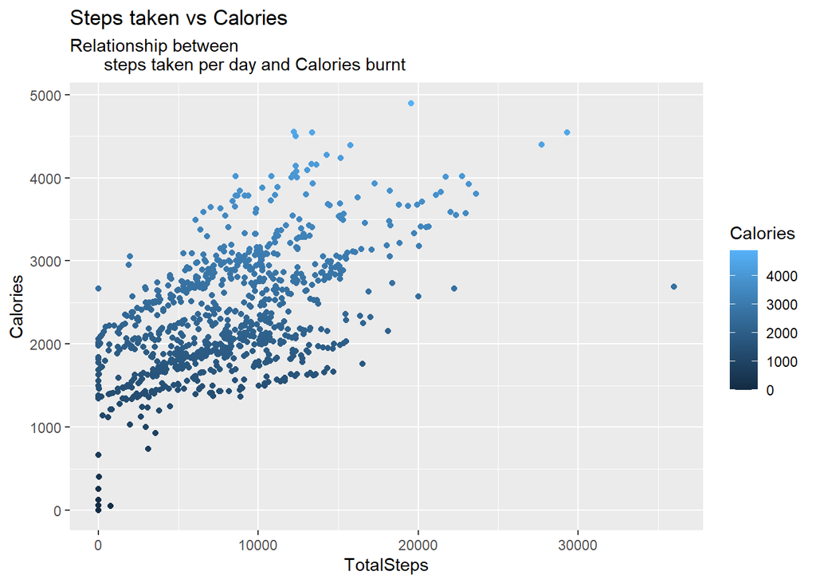

```r
ggplot(data=daily_activity,
       aes(x=TotalSteps, y=Calories, colour = Calories)) +
  geom_point()+
  labs(title = "Steps taken vs Calories", subtitle = "Relationship between
       steps taken per day and Calories burnt")
```

## What’s the relationship between minutes asleep and time in bed?

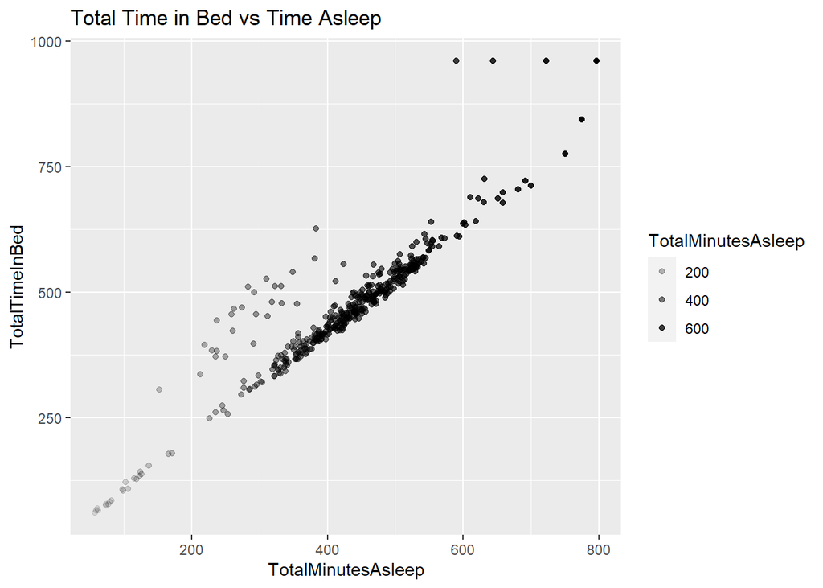

```r
ggplot(data=sleep_day,
       aes(x=TotalMinutesAsleep, y=TotalTimeInBed, alpha = TotalMinutesAsleep)) +
  geom_point()+ labs(title = "Total Time in Bed vs Time Asleep")
```

```r
sleep_day %>% select(TotalTimeInBed, TotalMinutesAsleep) %>%
  summary()
```

```
##  TotalTimeInBed  TotalMinutesAsleep
##  Min.   : 61.0   Min.   : 58.0
##  1st Qu.:403.0   1st Qu.:361.0
##  Median :463.0   Median :433.0
##  Mean   :458.6   Mean   :419.5
##  3rd Qu.:526.0   3rd Qu.:490.0
##  Max.   :961.0   Max.   :796.0
```

The relationship is not completely linear, indicating that individuals are spending more time in bed but are not sleeping. The company can invest create an App that locks you out of your phone for a period of 7 hours.

## Merging datasets together, sleep day and daily activity by ID column

```r
combined_data <- merge(sleep_day, daily_activity, by = "Id", all.x = TRUE, all.y = TRUE)
```

```r
n_distinct(combined_data$Id)
```

```
## [1] 33
```

#Exploring the combined data

```r
combined_data_clean <- na.omit(combined_data)
```

Relationship between sedentary minutes and sleep duration.

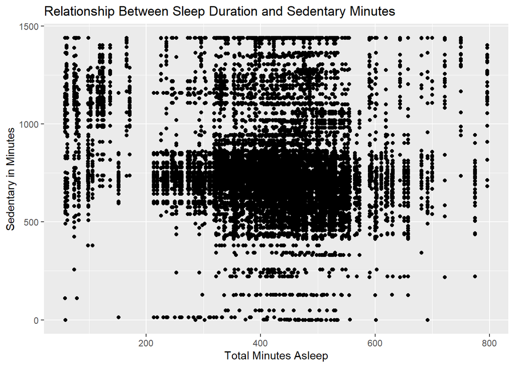

```r
ggplot(combined_data, aes(x = TotalMinutesAsleep, y = SedentaryMinutes)) +
  geom_point() +
  labs(
    x = "Total Minutes Asleep",
    y = "Sedentary in Minutes",
    title = "Relationship Between Sleep Duration and Sedentary Minutes"
  )
```

We check if there is a relationship between Sleep duration and Steps taken in a day using both geom_point in ggplot2 and cor in R.

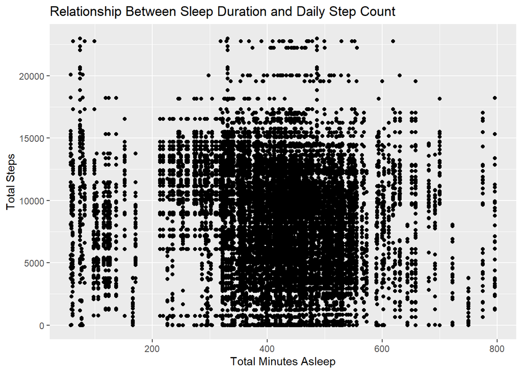

```r
ggplot(combined_data_clean, aes(x = TotalMinutesAsleep, y = TotalSteps)) +
  geom_point() +
  labs(
    x = "Total Minutes Asleep",
    y = "Total Steps",
    title = "Relationship Between Sleep Duration and Daily Step Count"
  )
```

```r
correlation <- cor(combined_data_clean$TotalMinutesAsleep, combined_data_clean$TotalSteps)
correlation
```

```
## [1] -0.09854146
```

The correlation is -0.0985 indicating that there may not be a strong linear relationship between sleep duration and daily step count.

## Steps

Summary Statistics for combined data

```r
combined_data %>%
  select(TotalSteps) %>%
  summary()
```

```
##    TotalSteps
##  Min.   :    0
##  1st Qu.: 4676
##  Median : 8582
##  Mean   : 8124
##  3rd Qu.:11207
##  Max.   :36019
```

The average steps taken by candidates is 8124. Maximum steps taken is 36019.

We will classify them into four groups such as: For general fitness, most adults should aim for 10,000 steps per day, with fewer than 5,000 steps being a sign of a sedentary lifestyle. However, the number will depend on a person’s age, current fitness level, and health goals. This recommendation comes from the Centers for Disease Control and Prevention (CDC)

Sedentary - less than 5000 steps a day. Lightly active - between 5000 and 7500 steps per day. fairly active - between 7500 and 10000 steps per day. Very active - more than 10000 steps per day

```r
combined_data_clean <- combined_data_clean %>%
  group_by (Id) %>%
  summarise(avg_daily_steps= mean(TotalSteps),
            avg_daily_cal= mean(Calories),
            avg_daily_sleep= mean(TotalMinutesAsleep,
                                   na.rm = TRUE)) %>%
  mutate(user_type= case_when(
    avg_daily_steps < 5000 ~ "sedentary",
    avg_daily_steps >= 5000 & avg_daily_steps <7499 ~"lightly active",
    avg_daily_steps >= 7499 & avg_daily_steps <9999 ~"fairly active",
    avg_daily_steps >= 10000 ~"very active"
  ))

head(combined_data_clean)
```

```
## # A tibble: 6 × 5
##           Id avg_daily_steps avg_daily_cal avg_daily_sleep user_type
##        <dbl>           <dbl>         <dbl>           <dbl> <chr>
## 1 1503960366          12117.         1816.            360. very active
## 2 1644430081           7283.         2811.            294  lightly active
## 3 1844505072           2580.         1573.            652  sedentary
## 4 1927972279            916.         2173.            417  sedentary
## 5 2026352035           5567.         1541.            506. lightly active
## 6 2320127002           4717.         1724.             61  sedentary
```

```r
percentages_user_type_steps <- combined_data_clean %>%
group_by(user_type) %>%
summarise(total= n()) %>%
mutate(total_percent= scales::percent (total/sum(total)))


head(percentages_user_type_steps)
```

```
## # A tibble: 4 × 3
##   user_type      total total_percent
##   <chr>          <int> <chr>
## 1 fairly active      8 33.3%
## 2 lightly active     4 16.7%
## 3 sedentary          7 29.2%
## 4 very active        5 20.8%
```

The summary shows 29% of the participants are living a sedentary life. We visualize the results;

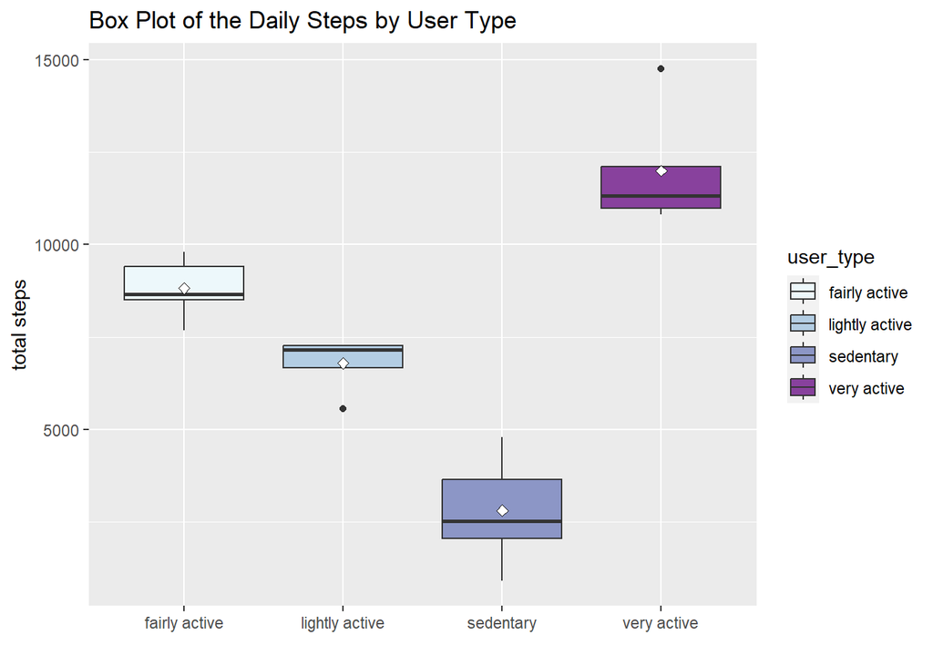

```r
ggplot(combined_data_clean[which(combined_data_clean$avg_daily_steps>0),],
       aes(user_type,avg_daily_steps, fill=user_type))+
  geom_boxplot()+
  stat_summary(fun="mean", geom="point",
               shape=23,size=2, fill="white")+
  labs(title= "Box Plot of the Daily Steps by User Type",
       x= " ", y="total steps")+
  scale_fill_brewer(palette="BuPu")
```

## We try to find out the most active days of the week

But first wee need to glimpse at the data;

```r
glimpse(daily_activity)
```

```
## Rows: 940
## Columns: 15
## $ Id                       <dbl> 1503960366, 1503960366, 1503960366, 150396036…
## $ ActivityDate             <chr> "4/12/2016", "4/13/2016", "4/14/2016", "4/15/…
## $ TotalSteps               <int> 13162, 10735, 10460, 9762, 12669, 9705, 13019…
## $ TotalDistance            <dbl> 8.50, 6.97, 6.74, 6.28, 8.16, 6.48, 8.59, 9.8…
## $ TrackerDistance          <dbl> 8.50, 6.97, 6.74, 6.28, 8.16, 6.48, 8.59, 9.8…
## $ LoggedActivitiesDistance <dbl> 0, 0, 0, 0, 0, 0, 0, 0, 0, 0, 0, 0, 0, 0, 0, …
## $ VeryActiveDistance       <dbl> 1.88, 1.57, 2.44, 2.14, 2.71, 3.19, 3.25, 3.5…
## $ ModeratelyActiveDistance <dbl> 0.55, 0.69, 0.40, 1.26, 0.41, 0.78, 0.64, 1.3…
## $ LightActiveDistance      <dbl> 6.06, 4.71, 3.91, 2.83, 5.04, 2.51, 4.71, 5.0…
## $ SedentaryActiveDistance  <dbl> 0, 0, 0, 0, 0, 0, 0, 0, 0, 0, 0, 0, 0, 0, 0, …
## $ VeryActiveMinutes        <int> 25, 21, 30, 29, 36, 38, 42, 50, 28, 19, 66, 4…
## $ FairlyActiveMinutes      <int> 13, 19, 11, 34, 10, 20, 16, 31, 12, 8, 27, 21…
## $ LightlyActiveMinutes     <int> 328, 217, 181, 209, 221, 164, 233, 264, 205, …
## $ SedentaryMinutes         <int> 728, 776, 1218, 726, 773, 539, 1149, 775, 818…
## $ Calories                 <int> 1985, 1797, 1776, 1745, 1863, 1728, 1921, 203…
```

We convert Activity date to date format

```r
#dealing with dates -load lubridate()
daily_activity_clean <- daily_activity %>%
  na.omit() %>%
  mutate(ActivityDate = as.Date(ActivityDate, format = "%m/%d/%Y"))


head(daily_activity_clean)
```

```
##           Id ActivityDate TotalSteps TotalDistance TrackerDistance
## 1 1503960366   2016-04-12      13162          8.50            8.50
## 2 1503960366   2016-04-13      10735          6.97            6.97
## 3 1503960366   2016-04-14      10460          6.74            6.74
## 4 1503960366   2016-04-15       9762          6.28            6.28
## 5 1503960366   2016-04-16      12669          8.16            8.16
## 6 1503960366   2016-04-17       9705          6.48            6.48
##   LoggedActivitiesDistance VeryActiveDistance ModeratelyActiveDistance
## 1                        0               1.88                     0.55
## 2                        0               1.57                     0.69
## 3                        0               2.44                     0.40
## 4                        0               2.14                     1.26
## 5                        0               2.71                     0.41
## 6                        0               3.19                     0.78
##   LightActiveDistance SedentaryActiveDistance VeryActiveMinutes
## 1                6.06                       0                25
## 2                4.71                       0                21
## 3                3.91                       0                30
## 4                2.83                       0                29
## 5                5.04                       0                36
## 6                2.51                       0                38
##   FairlyActiveMinutes LightlyActiveMinutes SedentaryMinutes Calories
## 1                  13                  328              728     1985
## 2                  19                  217              776     1797
## 3                  11                  181             1218     1776
## 4                  34                  209              726     1745
## 5                  10                  221              773     1863
## 6                  20                  164              539     1728
```

Create weekday column;

```r
Activity_by_week <- daily_activity_clean %>%
  mutate(weekday = weekdays(ActivityDate))

Activity_by_week$weekday <-ordered(Activity_by_week$weekday, levels=c("Monday", "Tuesday", "Wednesday", "Thursday",
"Friday", "Saturday", "Sunday"))

head(Activity_by_week)
```

```
##           Id ActivityDate TotalSteps TotalDistance TrackerDistance
## 1 1503960366   2016-04-12      13162          8.50            8.50
## 2 1503960366   2016-04-13      10735          6.97            6.97
## 3 1503960366   2016-04-14      10460          6.74            6.74
## 4 1503960366   2016-04-15       9762          6.28            6.28
## 5 1503960366   2016-04-16      12669          8.16            8.16
## 6 1503960366   2016-04-17       9705          6.48            6.48
##   LoggedActivitiesDistance VeryActiveDistance ModeratelyActiveDistance
## 1                        0               1.88                     0.55
## 2                        0               1.57                     0.69
## 3                        0               2.44                     0.40
## 4                        0               2.14                     1.26
## 5                        0               2.71                     0.41
## 6                        0               3.19                     0.78
##   LightActiveDistance SedentaryActiveDistance VeryActiveMinutes
## 1                6.06                       0                25
## 2                4.71                       0                21
## 3                3.91                       0                30
## 4                2.83                       0                29
## 5                5.04                       0                36
## 6                2.51                       0                38
##   FairlyActiveMinutes LightlyActiveMinutes SedentaryMinutes Calories   weekday
## 1                  13                  328              728     1985   Tuesday
## 2                  19                  217              776     1797 Wednesday
## 3                  11                  181             1218     1776  Thursday
## 4                  34                  209              726     1745    Friday
## 5                  10                  221              773     1863  Saturday
## 6                  20                  164              539     1728    Sunday
```

We visulize our findings;

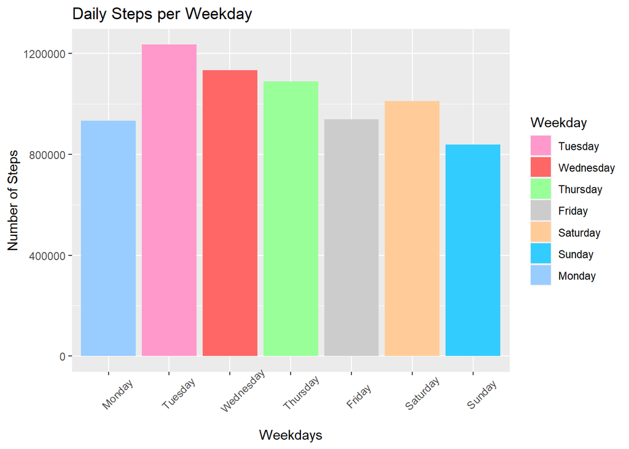

```r
# Define custom colors and labels
custom_colors_steps <- c('#ff99cc', '#ff6666', '#99ff99', '#cccccc', '#ffcc99', '#33ccff', '#99ccff')
weekday_labels <- unique(Activity_by_week$weekday)

ggplot(Activity_by_week) +
  geom_col(aes(weekday, TotalSteps, fill = weekday)) +
  scale_fill_manual(values = custom_colors_steps, breaks = weekday_labels, labels = weekday_labels) +  # Set custom colors and labels
  labs(title = "Daily Steps per Weekday", x = "Weekdays", y = "Number of Steps") +
  theme(axis.text.x = element_text(angle = 45, vjust = 0.5, hjust = 0.2)) +
  guides(fill = guide_legend(title = "Weekday"))  # Add legend title
```

We can use the dame to visualize sedentary by week.

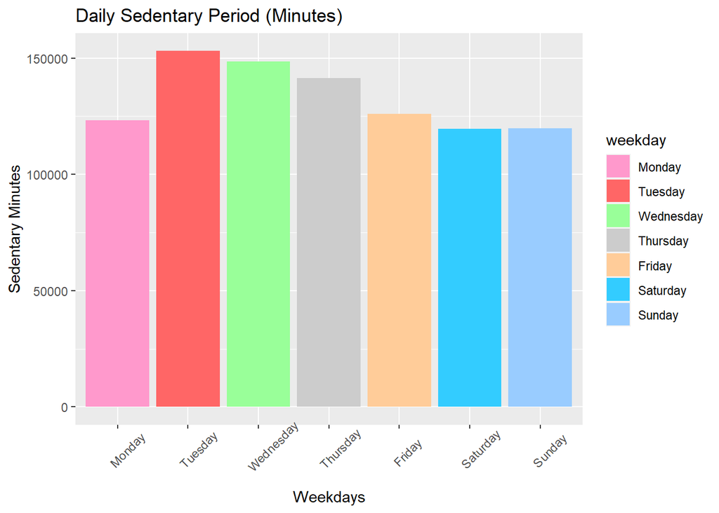

```r
custom_colors_r <- c('#ff99cc', '#ff6666', '#99ff99', '#cccccc', '#ffcc99', '#33ccff', '#99ccff')

ggplot(Activity_by_week) +
  geom_col(aes(weekday, SedentaryMinutes, fill = weekday)) +
  scale_fill_manual(values = custom_colors_r) +  # Set custom colors
  labs(title = "Daily Sedentary Period (Minutes)", x = "Weekdays", y = "Sedentary Minutes") +
  theme(axis.text.x = element_text(angle = 45, vjust = 0.5, hjust = 0.2))
```

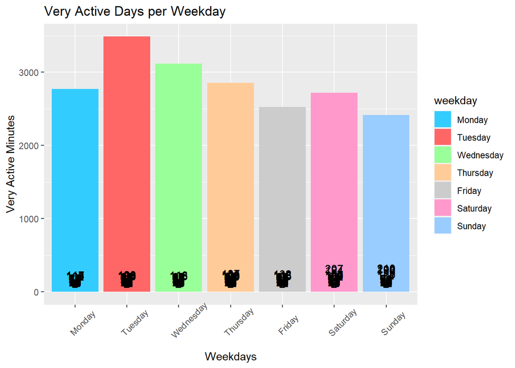

```r
# Define custom colors
custom_colors <- c('#33ccff', '#ff6666', '#99ff99', '#ffcc99', '#cccccc', '#ff99cc', '#99ccff')

ggplot(Activity_by_week) +
  geom_col(aes(weekday, VeryActiveMinutes, fill = weekday)) +
  geom_text(aes(weekday, VeryActiveMinutes, label = VeryActiveMinutes), vjust = -0.5) +  # Add labels
  labs(title = "Very Active Days per Weekday", x = "Weekdays", y = "Very Active Minutes") +
  scale_fill_manual(values = custom_colors) +  # Set custom colors
  theme(axis.text.x = element_text(angle = 45, vjust = 0.5, hjust = 0.2))
```

## Conclusion

Recommendations for Bellabeat Marketing Strategy:

Develop features and notifications in the fitness watch and app that encourage users to increase their daily activity. Segment users to offer challenges, rewards, and reminders to meet the personalized activity goals based on each user’s fitness level and progress.

Implement features that help users reduce sedentary hours. These could include information on standing desks for work, reminders to stand or move after prolonged inactivity. Offer features that track and display sedentary time, helping users become more aware of their habits.

Highlight the sleep tracking features of the fitness watches in marketing materials. Promote the connection between time in bed and time a sleep. Educate users about the benefits of adequate sleep for overall health and introduce apps that locks you out of your phone when you are in bed.

Develop marketing campaigns and resources aimed at heavy users. Showcase specialized fitness plans, nutritional guidance, and support services tailored to their needs.